# Working with HAML: Converting and Processing HLA Antibody Data

Demo scripts for the HAML 1.0 specification

Authors

Affiliations

Vanessa W. Menard

Tulane University School of Medicine

Loren Gragert

Tulane University School of Medicine

Eric Spierings

University Medical Center Utrecht

Ben Matern

National Marrow Donor Program

## Introduction

This document walks through three fundamental operations with HLA Antibody Markup Language (HAML):

1. **Convert** a laboratory CSV export into standardized HAML XML
2. **Analyze** the HAML file by applying an MFI threshold to classify beads
3. **Virtual Crossmatch** using HAML antibody data and donor HLA typing

Each section is self-contained and can be adapted for your own data.

### What is HAML?

HLA single antigen bead (SAB) assays are the standard technology for identifying HLA antibodies in transplant patients. Every transplant center in the US uses them. But the raw data, mean fluorescence intensity (MFI) values for each bead, is exported in vendor-specific CSV formats that differ between One Lambda (Thermo Fisher), Werfen (Immucor), and institutional laboratory information systems.

**HAML** (HLA Antibody Markup Language) is an XML-based standard that provides a single, vendor-neutral format for SAB assay results. It captures raw MFI values, bead metadata, assay kit information, adjusted calculations, and interpretation results. HAML was developed by the [IHIW](https://www.ihiw.org/) Clinical Histocompatibility Laboratory Informatics Working Group.

```python
import sys
from pathlib import Path

REPO_ROOT = Path("..").resolve()
sys.path.insert(0, str(REPO_ROOT / "scripts"))

import pandas as pd
from lxml import etree
```

## Part 1: Converting SAB Data to HAML

The most common starting point is a CSV export from laboratory analysis software. Here we convert a One Lambda HLA Fusion export into HAML XML.

### Input: One Lambda Fusion CSV

The standard export has one row per bead with columns for sample ID, bead ID, HLA specificity, raw MFI, and bead count. Beads 1 and 2 are negative and positive controls (no specificity assigned).

```python
csv_path = REPO_ROOT / "data" / "sample_sab_class1.csv"
df_input = pd.read_csv(csv_path)

print(f"Input: {csv_path.name}")
print(f"Beads: {len(df_input)} rows, {df_input['Sample ID'].nunique()} sample(s)\n")
df_input.head(10)
```

```
Input: sample_sab_class1.csv
Beads: 89 rows, 1 sample(s)
```

|  | Sample ID | Bead ID | Specificity | Raw Value | BCM | Ranking | Bead Count |
| --- | --- | --- | --- | --- | --- | --- | --- |
| 0 | HAML-DEMO-001 | 1 | NaN | 45.0 | NaN | NaN | 98 |
| 1 | HAML-DEMO-001 | 2 | NaN | 18250.0 | NaN | NaN | 102 |
| 2 | HAML-DEMO-001 | 3 | A*01:01 | 312.0 | 6.9 | 8.0 | 88 |
| 3 | HAML-DEMO-001 | 4 | A*02:01 | 8542.0 | 189.8 | 1.0 | 95 |
| 4 | HAML-DEMO-001 | 5 | A*02:03 | 7891.0 | 175.4 | 1.0 | 91 |
| 5 | HAML-DEMO-001 | 6 | A*02:06 | 6104.0 | 135.6 | 1.0 | 89 |
| 6 | HAML-DEMO-001 | 7 | A*03:01 | 487.0 | 10.8 | 7.0 | 94 |
| 7 | HAML-DEMO-001 | 8 | A*11:01 | 1245.0 | 27.7 | 4.0 | 90 |
| 8 | HAML-DEMO-001 | 9 | A*11:02 | 1102.0 | 24.5 | 5.0 | 87 |
| 9 | HAML-DEMO-001 | 10 | A*23:01 | 215.0 | 4.8 | 8.0 | 92 |

### Conversion

The converter maps each CSV row into the HAML document hierarchy. Each bead becomes a `target-bead-observation` element with `bead-info` (HLA specificity) and `bead-raw-data` (MFI value).

```python
from csv_to_haml import read_fusion_csv, build_haml, validate_haml

beads = read_fusion_csv(csv_path)
root = build_haml(beads, reporting_center="HAML Demo Laboratory")

xml_bytes = etree.tostring(root, pretty_print=True, xml_declaration=True, encoding="UTF-8")
xml_str = xml_bytes.decode("utf-8")

lines = xml_str.split("\n")
print(f"Generated HAML XML: {len(lines)} lines\n")
print("\n".join(lines[:40]))
print(f"\n... ({len(lines) - 40} more lines)")
```

```
Generated HAML XML: 1012 lines

<?xml version='1.0' encoding='UTF-8'?>
<haml xmlns="urn:HAML.Namespace" version="0.5.3">
  <haml-id>
    <root>0.0.0.0</root>
    <extension>haml-demo-HAML-DEMO-001</extension>
  </haml-id>
  <reporting-center>HAML Demo Laboratory</reporting-center>
  <patient>
    <patient-id>HAML-DEMO-001</patient-id>
    <sample>
      <sample-id>HAML-DEMO-001-serum</sample-id>
      <sample-date>2026-04-21</sample-date>
      <sample-type>Serum</sample-type>
      <working-sample>
        <working-sample-id>HAML-DEMO-001-NEAT</working-sample-id>
        <treatment>
          <method>NEAT</method>
        </treatment>
        <assay>
          <assay-id>HAML-DEMO-001-SAB-CI</assay-id>
          <run-id>RUN-HAML-DEMO-001</run-id>
          <assay-date>2026-04-21</assay-date>
          <assay-kit>
            <assay-type>Solid Phase Assay</assay-type>
            <catalog-number>LS1A04</catalog-number>
            <lot-number>DEMO-001</lot-number>
            <kit-manufacturer>One Lambda (Thermo Fisher)</kit-manufacturer>
            <interpretation-software>HLA Fusion</interpretation-software>
          </assay-kit>
          <target-bead-observation>
            <bead-info>
              <bead-id>1</bead-id>
              <bead-type>negative-control</bead-type>
            </bead-info>
            <bead-raw-data>
              <raw-MFI>45.0</raw-MFI>
              <bead-count>98</bead-count>
            </bead-raw-data>
          </target-bead-observation>
          <target-bead-observation>

... (972 more lines)
```

### Schema Validation

The XSD schema enforces structural correctness. Any HAML consumer can validate a file before processing.

```python
is_valid, errors = validate_haml(root)
if is_valid:
    print("XSD Validation: PASSED")
else:
    print(f"XSD Validation: FAILED\n{errors}")
```

```
XSD Validation: PASSED
```

## Part 2: MFI Threshold Classification

Now we read the HAML file back and classify each bead by applying a 2,000 MFI threshold.

```python
from haml_analyzer import parse_haml_beads, classify_bead, extract_locus

output_dir = REPO_ROOT / "output"
output_dir.mkdir(exist_ok=True)
haml_path = output_dir / "demo_class1.haml.xml"
with open(haml_path, "w") as f:
    f.write(xml_str)

all_beads = parse_haml_beads(haml_path)
target_beads = [b for b in all_beads if b["bead_type"] == "target"]

nc = next((b for b in all_beads if b["bead_type"] == "negative-control"), None)
pc = next((b for b in all_beads if b["bead_type"] == "positive-control"), None)

THRESHOLD = 2000

print(f"Target beads: {len(target_beads)}")
print(f"NC: {nc['raw_mfi']:.0f}  |  PC: {pc['raw_mfi']:.0f}  |  PC/NC: {pc['raw_mfi']/nc['raw_mfi']:.1f}")
print(f"Threshold: {THRESHOLD} MFI\n")

rows = []
for b in target_beads:
    rows.append({
        "specificity": b["hla_specificity"],
        "locus": extract_locus(b["hla_specificity"]),
        "raw_mfi": b["raw_mfi"],
        "classification": classify_bead(b["raw_mfi"], THRESHOLD),
    })
df = pd.DataFrame(rows)

positives = df[df["classification"] == "Positive"].sort_values("raw_mfi", ascending=False)
print(f"Positive: {len(positives)}  |  Borderline: {(df['classification']=='Borderline').sum()}  |  Negative: {(df['classification']=='Negative').sum()}\n")
positives[["specificity", "locus", "raw_mfi"]]
```

```
Target beads: 87
NC: 45  |  PC: 18250  |  PC/NC: 405.6
Threshold: 2000 MFI

Positive: 9  |  Borderline: 3  |  Negative: 75
```

|  | specificity | locus | raw_mfi |
| --- | --- | --- | --- |
| 1 | A*02:01 | A | 8542.0 |
| 23 | A*68:01 | A | 8123.0 |
| 2 | A*02:03 | A | 7891.0 |
| 24 | A*68:02 | A | 7654.0 |
| 25 | A*69:01 | A | 6890.0 |
| 3 | A*02:06 | A | 6104.0 |
| 47 | B*44:03 | B | 5123.0 |
| 46 | B*44:02 | B | 4890.0 |
| 28 | B*07:02 | B | 4521.0 |

### MFI Distribution

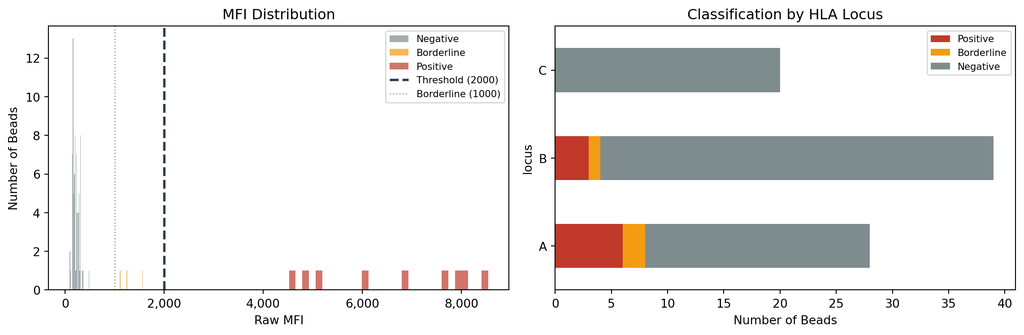

Figure 1: MFI distribution across all Class I beads with threshold classification

```python
import matplotlib.pyplot as plt
import matplotlib.ticker as ticker

fig, axes = plt.subplots(1, 2, figsize=(12, 4))

colors = {"Positive": "#c0392b", "Borderline": "#f39c12", "Negative": "#7f8c8d"}
ax = axes[0]
for cls in ["Negative", "Borderline", "Positive"]:
    subset = df[df["classification"] == cls]
    ax.hist(subset["raw_mfi"], bins=30, alpha=0.7, label=cls, color=colors[cls])
ax.axvline(x=THRESHOLD, color="#2c3e50", linestyle="--", linewidth=2, label=f"Threshold ({THRESHOLD})")
ax.axvline(x=THRESHOLD*0.5, color="#95a5a6", linestyle=":", linewidth=1, label=f"Borderline ({int(THRESHOLD*0.5)})")
ax.set_xlabel("Raw MFI")
ax.set_ylabel("Number of Beads")
ax.set_title("MFI Distribution")
ax.legend(fontsize=8)
ax.xaxis.set_major_formatter(ticker.FuncFormatter(lambda x, _: f"{x:,.0f}"))

ax2 = axes[1]
summary = df.groupby("locus")["classification"].value_counts().unstack(fill_value=0)
summary = summary.reindex(columns=["Positive", "Borderline", "Negative"], fill_value=0)
summary.plot(kind="barh", stacked=True, ax=ax2, color=[colors["Positive"], colors["Borderline"], colors["Negative"]])
ax2.set_xlabel("Number of Beads")
ax2.set_title("Classification by HLA Locus")
ax2.legend(fontsize=8)

plt.tight_layout()
plt.show()
```

## Part 3: Simple Virtual Crossmatch

A virtual crossmatch (VXM) predicts whether a patient’s antibodies will react against a specific donor’s HLA antigens. The basic logic: any positive antibody matching a donor allele is a donor-specific antibody (DSA), predicting a positive crossmatch.

```python
from simple_vxm import read_donor_typing, identify_dsa, predict_vxm

donor_path = REPO_ROOT / "data" / "sample_donor_typing.txt"
donor_alleles = read_donor_typing(donor_path)

print("Donor HLA Typing:")
for allele in sorted(donor_alleles):
    print(f"  {allele}")
```

```
Donor HLA Typing:
  A*02:01
  A*30:01
  B*07:02
  B*44:02
  C*05:01
  C*07:02
  DPA1*01:03
  DPB1*04:01
  DQA1*03:01
  DQB1*03:02
  DRB1*04:01
  DRB1*15:01
  DRB4*01:01
  DRB5*01:01
```

```python
# Class I DSA
dsa_c1 = identify_dsa(all_beads, donor_alleles, threshold=THRESHOLD)

# Class II: convert, parse, find DSA
csv_path_c2 = REPO_ROOT / "data" / "sample_sab_class2.csv"
beads_c2 = read_fusion_csv(csv_path_c2)
root_c2 = build_haml(beads_c2, reporting_center="HAML Demo Laboratory", hla_class="II", catalog="LS2A01")
haml_c2 = output_dir / "demo_class2.haml.xml"
with open(haml_c2, "w") as f:
    f.write(etree.tostring(root_c2, pretty_print=True, xml_declaration=True, encoding="UTF-8").decode())
dsa_c2 = identify_dsa(parse_haml_beads(haml_c2), donor_alleles, threshold=THRESHOLD)

all_dsa = dsa_c1 + dsa_c2

print(f"MFI Threshold: {THRESHOLD}\n")
if all_dsa:
    dsa_df = pd.DataFrame(all_dsa).sort_values("raw_mfi", ascending=False)
    print(f"Donor-Specific Antibodies ({len(all_dsa)} found):\n")
    print(dsa_df[["specificity", "locus", "raw_mfi", "match_type"]].to_string(index=False))

print(f"\nVirtual Crossmatch Prediction: {predict_vxm(all_dsa)}")
```

```
MFI Threshold: 2000

Donor-Specific Antibodies (5 found):

          specificity locus  raw_mfi        match_type
              A*02:01     A   8542.0             exact
              B*44:02     B   4890.0             exact
DQA1*03:01~DQB1*03:02    DQ   4567.0 heterodimer-chain
              B*07:02     B   4521.0             exact
           DRB1*04:01  DRB1   3456.0             exact

Virtual Crossmatch Prediction: Positive (Incompatible)
```

## Discussion

This notebook demonstrated the core value of HAML: **a single workflow that works regardless of which laboratory produced the data**. The same analyzer and VXM scripts work on HAML files generated from any vendor’s CSV export, because the HAML schema standardizes the representation.

### What This Demo Does NOT Cover

Clinical antibody interpretation involves locus-specific thresholds, cross-reactive group (CREG) analysis, artifact detection (prozone, complement interference), historical antibody patterns, platform concordance, and eplet-level molecular analysis. These capabilities require domain-specific algorithms beyond simple threshold classification.